# Check and recode variables

#### Date: 2024-05-24

### Table 1. StudyID

| Times tested | n_patients |
| --- | --- |
| 1 | 2443 |
| 2 | 508 |
| 3 | 114 |
| 4 | 28 |
| 5 | 11 |
| 6 | 4 |

There are 3108 patients in the original main dataset. There are 2443 patients tested only once, and 665 patients were tested more than once.

### Figure 1. Display age at testing and remove records above 1 yo

- Remove records with (collection date - DOB) > 12 months. (TBC? age limit?)
- Generated age_at_testing_in_days, age_at_testing_in_months.

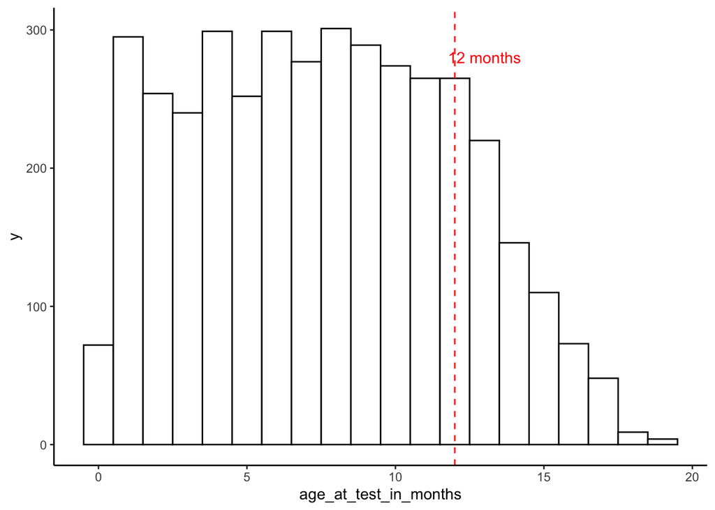

#### There are 724 testing records having age > 12 months at the time of testing. Removed these records from current dataset.

### Table 2. Times tested

| Times tested | n_patients |
| --- | --- |
| 1 | 2089 |
| 2 | 399 |
| 3 | 86 |
| 4 | 19 |
| 5 | 7 |
| 6 | 2 |

After removing records > 12 months at testing, there are 2602 patients in the dataset. There are 2089 patients tested only once, and 513 patients were tested more than once.

StudyID for those who were tested 5 timese: 130646244, 130705659, 130709635, 130749578, 130752957, 130755900, 130759159. StudyID for those who were tested 6 timese: 130654546, 130719972.

### Table 3 Sex

recode unknown to NA.

| Sex | n |
| --- | --- |
| Female | 1413 |
| Male | 1854 |
| Unknown | 1 |

### Figure 2. Sex & Age at testing (after removing age at testing > 1 yo)

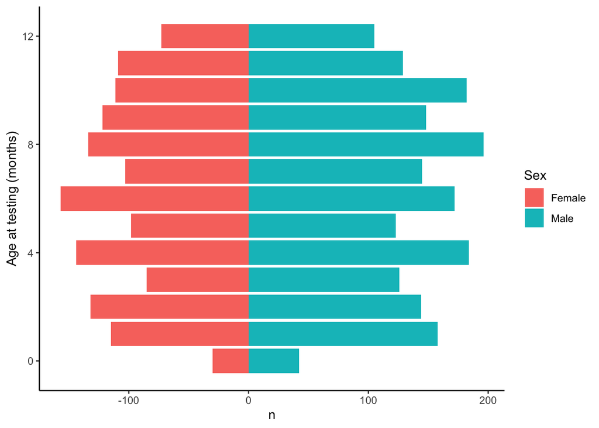

### Figure 3 Collection Date (sample collection date)

Generate collection_date (Date class varaible).

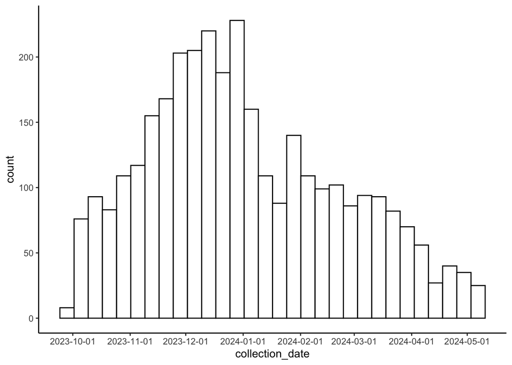

Sample collection date: 2023-09-30 ~ 2024-05-09.

### Viral test, Resp Result, Viral detected:

#### From these variables, generate variables:

- tested_xxx: indicating whether this record was tested for certain virus
- positive_xxx: the testing results for certain virus (flu,rhino,hmpv,adeno,parainfluenza,rsv).

#### From tested_xxx and positive_xxx, generate new variable:

- tested_viruses: string class, listing viruses tested for a record (some viruses are not listed here, like covid)
- positive_viruses: string class, listing viruses tested positive for a record (some viruses are not listed here, like covid)

#### what tests are included in “RESPIRATORY VIRUS PCR PANEL (BH GH LMW Q YH) [LAB3444]”? (TBC)

### Table 4. Viral test (taken by a record)

| tested_viruses | n_records |
| --- | --- |
| flu rsv | 3100 |
| flu rhino hmpv adeno parainfluenza rsv | 153 |
| rsv | 15 |

This table shows the number of testing records (w/ duplicates) that took certain tests, some viruses are not included here (like SARS-CoV-2).

### Table 5. Viral test results (by virus combo)

Listing all the combinations of viral test results. Each record contributes one virus combo.

| positive_viruses | n_records |
| --- | --- |
| NO detection of any viruses | 2326 |
| rsv | 726 |
| fluA | 146 |
| fluB | 23 |
| rhino | 20 |
| parainfluenza | 5 |
| fluA rsv | 4 |
| hmpv | 4 |
| adeno | 3 |
| adeno rsv | 2 |

[output cut: 7 more lines]

### Table 6. Viral test results (by single virus)

Listing viruses tested positive, each record can contribute one or more as one record can be tested positive for multiple viruses.

| Virus | n_records | perc |
| --- | --- | --- |
| No.detection | 2326 | 71.2 |
| rsv | 735 | 22.5 |
| fluA | 150 | 4.6 |
| rhino | 27 | 0.8 |
| fluB | 23 | 0.7 |
| adeno | 9 | 0.3 |
| parainfluenza | 8 | 0.2 |
| hmpv | 6 | 0.2 |

### Table 7. Admit Date

There might be some uncertainty about this variable so we might not trust this 100%. Here calculated time difference (in days) between Admit Date and sample collection. (this variable might not be that useful in the actual analyses.)

| days_btw_admit_collect | n |
| --- | --- |
| -1 | 60 |
| 0 | 3033 |
| 1 | 100 |
| 2 | 2 |
| 3 | 5 |
| 4 | 2 |
| 5 | 5 |
| 6 | 4 |
| 7 | 1 |
| 8 | 4 |

[output cut: 37 more lines]

### Table 8. Hosp LoS

Length of Stay (in days) of hospitalization recorded in the main dataset. **Can this be a measure of severity?**

| Hosp LoS | n |
| --- | --- |
| 1 | 2946 |
| 2 | 106 |
| 3 | 47 |
| 4 | 22 |
| 5 | 18 |
| 6 | 10 |
| 7 | 8 |
| 8 | 3 |
| 9 | 5 |
| 10 | 5 |

[output cut: 49 more lines]

- Hosp LOS for “Emergency”, “Specimen”, “Outpatient”, “Hospital Outpatient Surgery” encounter type: all are 1 day;
- Hosp LOS for “Observation” encounter type: all but 2 records are 2 days, others all 1 day;
- Hosp LOS for “Newborn” encounter type: range from 3-287 days

#### There are 15 records missing Hosp LoS: (these are all records from BH EMERGENCY DEPARTMENT)

**Can I recode the Hosp LoS of these to 1 (TBC)?**

| StudyID | collection_date | Collection Department | tested_viruses | positive_viruses |
| --- | --- | --- | --- | --- |
| 130613579 | 2023-11-27 | BH EMERGENCY DEPARTMENT | flu rsv | rsv |
| 130626475 | 2024-01-30 | BH EMERGENCY DEPARTMENT | flu rsv | fluA |
| 130635648 | 2024-01-23 | BH EMERGENCY DEPARTMENT | flu rsv | NA |
| 130637034 | 2023-12-18 | BH EMERGENCY DEPARTMENT | flu rsv | NA |
| 130667931 | 2023-12-14 | BH EMERGENCY DEPARTMENT | flu rsv | NA |
| 130678248 | 2023-10-24 | BH EMERGENCY DEPARTMENT | flu rsv | NA |
| 130705752 | 2024-02-15 | BH EMERGENCY DEPARTMENT | flu rsv | rsv |
| 130719463 | 2024-03-13 | BH EMERGENCY DEPARTMENT | flu rsv | NA |
| 130727949 | 2024-02-21 | BH EMERGENCY DEPARTMENT | flu rsv | fluA |
| 130733035 | 2024-02-12 | BH EMERGENCY DEPARTMENT | flu rsv | NA |

[output cut: 5 more lines]

### Table 9. Collection Department & Admission location

#### Recode these two to sample_source variable (might not use this variable?):

- if Admission Location is available, use Admission Location;
- if Admission Location is not available, use Collection Department.

| sample_source | n |
| --- | --- |
| YNH 20 YORK ST | 1252 |
| BH 267 GRANT ST | 916 |
| GH 5 PERRYRIDGE RD | 374 |
| LMH 365 MONTAUK AVE | 238 |
| YNH MAIN LAB | 122 |
| LMH 52 HAZELNUT HILL RD | 66 |
| BH 309 STILLSON RD | 60 |
| WH DRAW STATION MORGAN BLDG | 39 |
| WH 25 WELLS ST | 27 |
| GH LABORATORY SPECIMENS | 26 |

[output cut: 19 more lines]

### Table 10. Original Encounter type

This is the Encounter Type recorded in the original main dataset.

| Encounter Type | n |
| --- | --- |
| Emergency | 2243 |
| Inpatient | 417 |
| Specimen | 330 |
| Observation | 176 |
| Newborn | 39 |
| NA | 35 |
| Outpatient | 27 |
| Hospital Outpatient Surgery | 1 |

### Table 11. Records missing Encounter type

There are 35 missings for original “encounter type” variable. Most seem to be from LABs or DRAW STATION except one record from “NE PEDS OLD SAYBROOK”, **can I classify them as “Specimen” ? (TBC)**

| StudyID | Collection Department | Admission Location | Encounter Type |
| --- | --- | --- | --- |
| 130618380 | YNH MAIN LAB | FHC 150 SARGENT DR | NA |
| 130637897 | YNH MAIN LAB | FHC 150 SARGENT DR | NA |
| 130664143 | YNH MAIN LAB | FHC 150 SARGENT DR | NA |
| 130690479 | YNH MAIN LAB | FHC 150 SARGENT DR | NA |
| 130741285 | YNH MAIN LAB | FHC 150 SARGENT DR | NA |
| 130718972 | YNH DRAW STATION E H MAIN ST | FHC 374 GRAND AVE | NA |
| 130688726 | BH FAM MED DRAW STATION QUARRY ROAD | NE 112 QUARRY ROAD | NA |
| 130583809 | YNH MAIN LAB | NE 2200 WHITNEY AVE | NA |
| 130584059 | YNH MAIN LAB | NE 2200 WHITNEY AVE | NA |
| 130615545 | YNH MAIN LAB | NE 2200 WHITNEY AVE | NA |

[output cut: 25 more lines]

### Table 12. Aggregate “Encounter Type” to fewer categories

#### Generated new variable: encounter_type, coded as:

- Emergency —> outpatient
- Outpatient —> outpatient
- Hospital Outpatient Surgery —> outpatient
- Specimen —> outpatient (TBC)
- Inpatient —> inpatient
- Observation —> inpatient? (TBC)
- Newborn —> inpatient? (TBC)

| encounter_type | n_records |
| --- | --- |
| inpatient | 632 |
| outpatient | 2601 |
| NA | 35 |

### Table 13. ICU admission date

#### Generated new variables:

- date_icu_admit: the same as ICU Admission Date but in Date class, N/A as NA;
- days_btw_collection_icu: days between sample collection and ICU admission.
- date_icu_admit_related: ICU admission that can be linked with the testing result (**within a week of sample collection date? TBC**)
- icu_admitted_related: binary variable indicating whether the icu can be related to the testing result (within a week of testing)

| days_btw_collection_icu | n |
| --- | --- |
| -3 | 1 |
| -2 | 1 |
| -1 | 14 |
| 0 | 63 |
| 1 | 4 |
| 2 | 3 |
| 3 | 4 |
| 4 | 2 |
| 5 | 5 |
| 6 | 2 |

[output cut: 39 more lines]

#### Out of 155 ICU admissions, 55 have ICU admission more than 7 days before or after sample collection date. We assume that these are ICU admissions that are not related to the testing result. Then the left ICU admissions:

### Figure 4. ICU admission date

These are ICU admissions within 7 days of sample collection date.

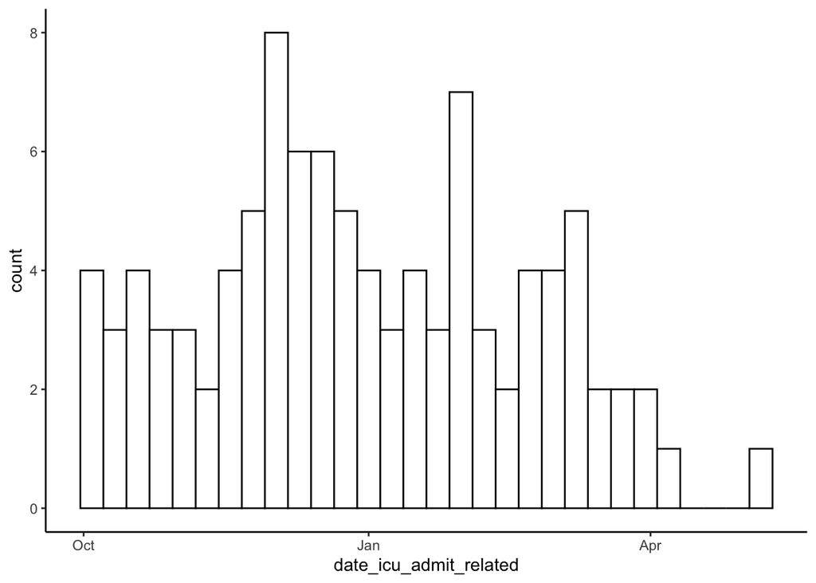

### Figure 5. ICU LOS

#### The original data was in XXd XXh format. Generate new variables:

- icu_los_hours (unit: hour)
- icu_los_days (unit: day)

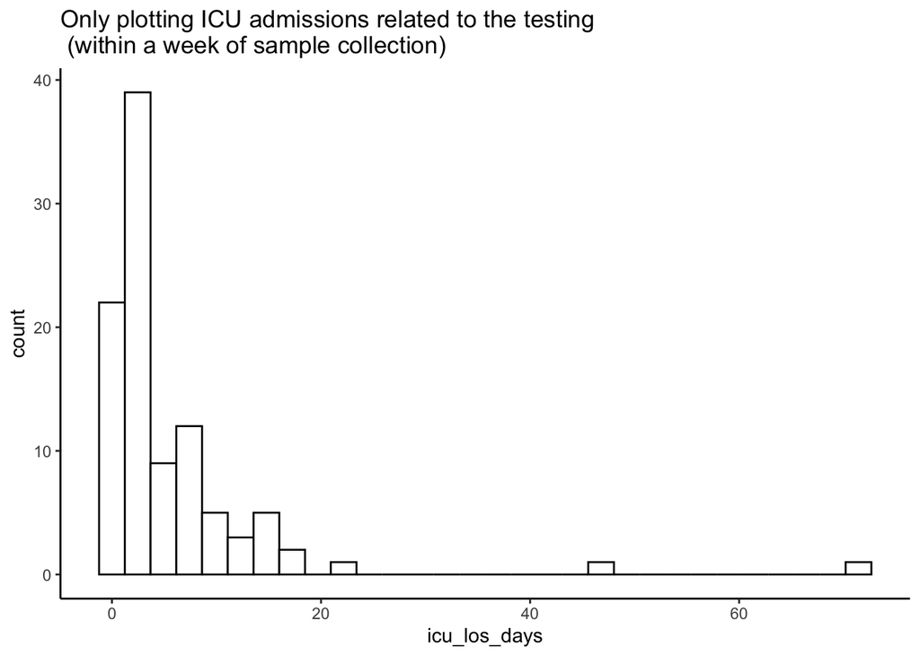

Several infants with ICU LOS longer than 1 month:

### Table 14.

| StudyID | Collection Date | date_icu_admit_related | icu_los_days |
| --- | --- | --- | --- |
| 130746598 | 2023-12-04T00:00:00Z | 2023-12-04 | 46.875 |
| 130767993 | 2024-01-24T00:00:00Z | 2024-01-18 | 71.875 |

### Figure 6. Gest age (as recorded in “Gest Age” variable)

There are ~700 records missing for original Gest Age variable.

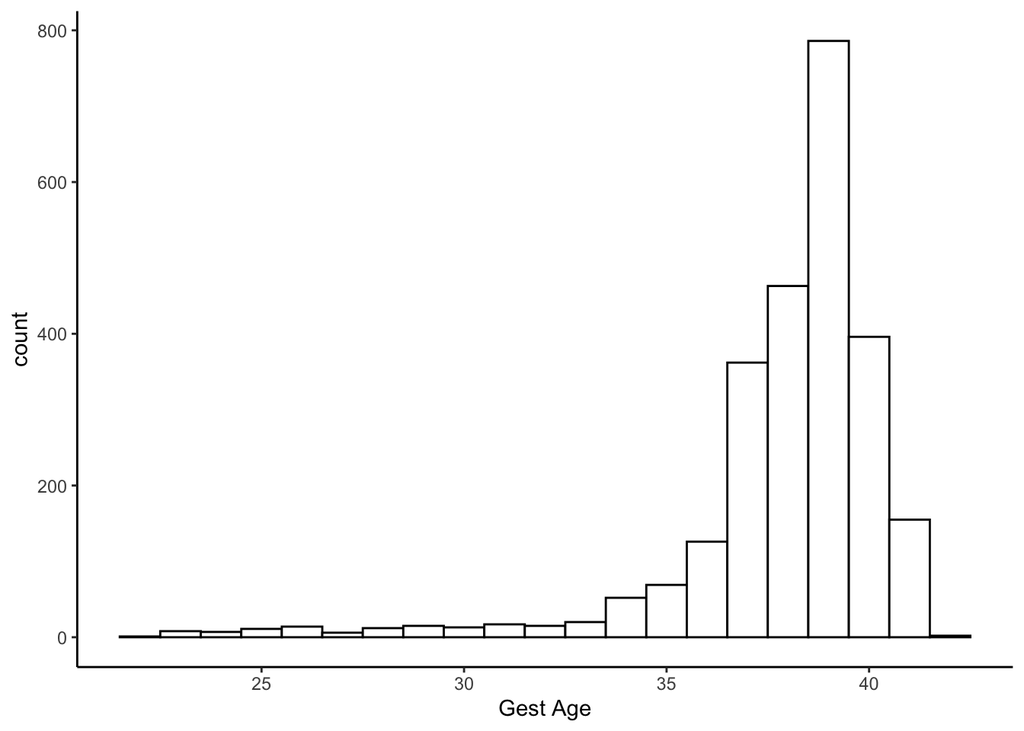

#### Generate categorical variable of gest age: gest_age_cat **(is the following classification okay? combine groups?)**

#### Reference: https://www.cdc.gov/nchs/data/nvsr/nvsr73/nvsr73-01.pdf

- 42 and +: post term
- 41: late term
- 39-40: full term
- 37-38: early term
- < 37: preterm

### Table 15. Gest Age (classified only using “Gest Age” variable)

#### In addition to “Gest Age” variable, I will also use Medical History, Problems.. variables to classify gestational age to fill in NA here, see below.

| gest_age_cat | n_records | perc |
| --- | --- | --- |
| full term | 1182 | 36.2 |
| early term | 825 | 25.2 |
| NA | 718 | 22 |
| preterm | 386 | 11.8 |
| late term | 155 | 4.7 |
| post term | 2 | 0.1 |

### Figure 7. Birth weight

- PENDING: Generate birth_weight_kg (numeric), low_birth_weight (binary). Low birth weight is defined as a birth weight of less than 2500 g (up to and including 2499 g), as per the World Health Organization (WHO).
- what is the unit of original variable Birth Wgt? Haven’t generated new variables (TBC?).

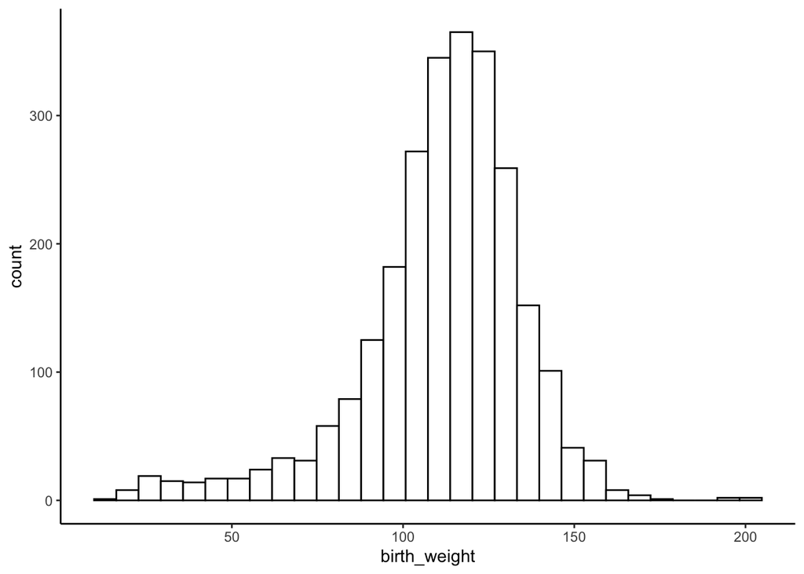

### Table 16. Race and Ethnicity (PENDING)

There are many conflicting answers (TBC?). Here are the unique answers for Race variable:

| Race | n |
| --- | --- |
| White | 1283 |
| I Do Not See My Race Listed Here | 745 |
| Black or African American | 608 |
| I Do Not Know | 235 |
| Asian | 77 |
| I Prefer Not To Share | 62 |
| Black or African American White | 40 |
| I Do Not See My Race Listed Here White | 28 |
| White Black or African American | 24 |
| NA | 19 |

[output cut: 38 more lines]

| Ethnicity | n |
| --- | --- |
| Not Hispanic or Latino/a/e | 1685 |
| Hispanic or Latino/a/e | 1351 |
| I Do Not Know | 150 |
| I Prefer Not To Share | 31 |
| Puerto Rican | 21 |
| NA | 18 |
| Mexican, Mexican American, Chicano/a | 12 |

### Table 17. Primary Insurance & Payor

#### Generate new variable insurance_type (TBC)

- Medicare / Medicaid —> public insurance
- All others —> private insurance
- Who are considered as “uninsured”? (patients having NA for Primary Insurance and Payor variable? n = 17)

| insurance_type | n_records |
| --- | --- |
| public | 2123 |
| private | 1128 |
| uninsured | 17 |

### Table 18. Fever?

This variable displays whether the patient had a fever according to the NHSN definition (>38 C) within three days of the collection date. The information appears as a Yes or a No.

| Fever? | n |
| --- | --- |
| No | 2255 |
| Yes | 1013 |

### Table 19. Temp

The most recent flowsheet data for temperature. Convert to new numeric variable recent_temp. (Might not be useful as this is the “most recent” temperature, but I used this below in generating symptom variables, if recent_temp>38, I considered this record had fever symptom.)

| recent_temp | n |
| --- | --- |
| 40.4 | 2 |
| 40.1 | 1 |
| 39.7 | 1 |
| 39.6 | 3 |
| 39.5 | 1 |
| 39.4 | 1 |
| 39.3 | 6 |
| 39.2 | 4 |
| 39.1 | 8 |
| 39 | 6 |

[output cut: 34 more lines]

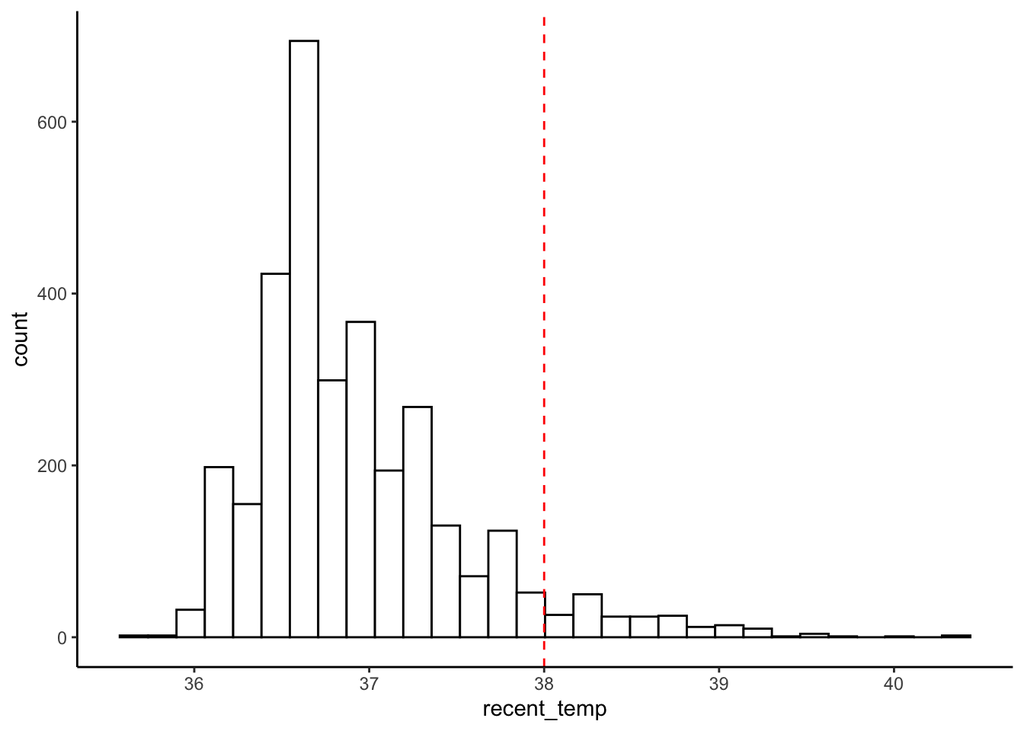

### Last PCP visit (haven’t processed)

### Last Well Child visit (haven’t processed)

### Recent contact (haven’t processed)

### Below are text patterns to detect risk factors (i.e. underlying conditions) and respiratory symptoms from the following variables (TBC):

- Medical History (past?) —> risk factors
- Problem List (past?) —> risk factors
- Primary Problem (current? TBC) —> risk factors & respiratory symptoms
- ED Dx (current? TBC) —> risk factors & respiratory symptoms
- Admit Dx (current? TBC) —> risk factors & respiratory symptoms
- Hospital Problem List (current? TBC) —> risk factors & respiratory symptoms

#### I detected the presence of these patterns to see if a record has certain risk factor (based on past and current encounters) or show a certain respiratory symptom in current encounter (based on diagnosis records of current encounter). The new variables generated are binary variables. For example, med_hist_congen_heart means that based on description in the “Medical History” variable, this records had congenital heart disease, which can be a risk factor for more severe outcomes.

```r
######################################
# patterns for underlying risk factors
######################################

pattern_anemia <- paste(c("anemia",
                          "S-C",
                          "thalassemia",
                          "Hemoglobin S-S disease",
                          "Sickle cell",
                          "sickle-cell",
                          "Hemoglobin S trait"),
                        collapse = "|")

pattern_asthma <- paste(c("asthma",
                          "Reactive airway disease"),
                        collapse = "|")


pattern_liver <- paste(c("liver cell damage",
                         "Liver cell injury",
                         "liver disease",
                         "Decompensated hepatic cirrhosis",
                         "Liver transplanted"),
                       collapse = "|")

pattern_cvd <- paste(c("Atrial septa",
                       "ventricular septa",
                 "Patent ductus arteriosus",
                 "Cardiac abnormality",
                 "Congenital heart disease",
                 "Partial AV canal",
                 "Ventricular septa",
                 "Coarctation of aorta",
                 "double outlet right ventricle",
                 "Dextrocardia",
                 "DORV",
                 "Cardiac abnormality",
                 "Heart murmur",
                 "Heart murmur of newborn",
                 "heart problem",
                 "Mitral regurgitation",
                 "Kawasaki disease",
                 "Coarctation of aorta",
                 "hemangioma",
                 "atrial septal defect",
                 "Thrombus of aorta",
                 "cardiac",
                 "murmur",
                 "premature atrial contraction",
                 "Cardiomegaly",
                 "Myocarditis",
                 "supraventricular tachycardia",
                 "Tetralogy of Fallot",
                 "Atrioventricular canal (AVC), complete",
                 "Heart failure",
                 "Aortic arch anomaly",
                 "supraventricular tachycardia",
                 "aortic coarctation",
                 "Enlarged heart"),
                 collapse = "|")


pattern_leukemia <- "leukemia"

pattern_gi <- paste(c("Abdominal distension",
                      "Acid reflux",
                      "gastroesophageal reflux",
                      "GI disease",
                      "Constipation",
                      "Esophageal atresia",
                      "Gastric perforation",
                      "Gastric reflux",
                      "Hirschsprung",
                      "GERD",
                      "Colostomy",
                      "necrotizing enterocolitis",
                      "Intestinal perforation",
                      "Intussusception",
                      "Biliary atresia",
                      "Ileostomy",
                      "esophageal reflux",
                      "Pyloric stenosis",
                      "Reflux gastritis",
                      "Gastric bleed",
                      "GI bleed",
                      "gastritis"),
                    collapse = "|")


pattern_congen_heart <- paste(c("Congenital heart disease",
                                "Coarctation of aorta",
                                "Congenital heart",
                                "D-TGA",
                                "double outlet right ventricle",
                                "Dextrocardia",
                                "DORV",
                                "Cardiac abnormality",
                                "ventricular septa",
                                "Mitral regurgitation",
                                "Coarctation of aorta",
                                "Hypoplastic aortic arch",
                                "atrial septal defect",
                                "Thrombus of aorta",
                                "Heart abnormality",
                                "Cardiomegaly",
                                "patent ductus arteriosus",
                                "Tetralogy of Fallot",
                                "Atrioventricular canal (AVC), complete",
                                "persistent left superior vena cava",
                                "Aortic arch anomaly",
                                "Wolff-Parkinson-White (WPW) syndrome",
                                "supraventricular tachycardia",
                                "Partial AV canal",
                                "Atrial septa",
                                "Heart murmur of newborn",
                                "supraventricular tachycardia",
                                "Partial anomalous pulmonary venous return",
                                "aortic coarctation",
                                "Congenital coronary artery fistula to pulmonary artery",
                                "Peripheral pulmonic stenosis",
                                "Tricuspid atresia with normal great arteries"),
                              collapse = "|")


pattern_pulmonary <- paste(c("Pulmonary valve atresia",
                             "Chronic cough",
                             "CPAM",
                             "Cystic fibrosis",
                             "Bronchopulmonary dysplasia",
                             "Protracted bacterial bronchitis",
                             "reactive airway disease",
                             "Pneumothorax",
                             "Pulmonary hypertension",
                             "Pulmonary valve stenosis",
                             "Bronchomalacia",
                             "Tracheomalacia",
                             "Partial anomalous pulmonary venous return",
                             "pulmonary artery stenosis",
                             "pulmonary artery",
                             "Peripheral pulmonic stenosis"),
                           collapse = "|")

pattern_down <- paste(c("Down syndrome",
                        "Trisomy 21"),
                      collapse = "|")

# 37-38 weeks
pattern_earlyterm <- paste(c("37 completed weeks",
                             "38 completed weeks",
                             "37 weeks gestation",
                             "38 weeks gestation"),
                           collapse = "|")

# 39-40 weeks
pattern_fullterm <- paste(c("39 completed weeks",
                            "39 weeks gestation",
                            "Term newborn",
                            "Term birth",
                            "40 completed weeks",
                            "40 weeks gestation"),
                          collapse = "|")

# < 37 weeks
pattern_preterm <- paste(c("Premature",
                           "prematurity",
                           "Extremely low birth weight",
                           "Preterm",
                           "36 weeks gestation",
                           "36 completed weeks",
                           "preterm newborn",
                           "preterm birth",
                           "33-34 completed weeks",
                           "29-30 completed weeks",
                           "35-36 completed weeks",
                           "34 completed weeks",
                           "35 completed weeks",
                           "22 weeks gestation"),
                         collapse = "|")

# >= 42 weeks
pattern_postterm <- paste(c("post-term",
                            "post term"),
                          collapse = "|")



######################################
# patterns for respiratory symptoms
######################################

# for upper respiratory tract diseases
pattern_URTI <- paste(c("Abnormal breathing",
                        "Breathing difficulty",
                        "difficulty breathing",
                        "breathing problem",
                        "Shortness of breath",
                        "cough",
                        "Acute obstructive laryngitis",
                        "pharyngitis",
                        "otitis media",
                        "upper respiratory infection",
                        "upper respiratory tract infection",
                        "croup",
                        "Nasopharyngitis",
                        "Pain in throat",
                        "reactive airway disease",
                        "Nasal congestion",
                        "wheezing",
                        "sore throat",
                        "URI",
                        "Laryngeal stridor"),
                      collapse = "|")

# for lower respiratory tract diseases:
pattern_LRTI <- paste(c("bronchiolitis",
                        "Laryngotracheobronchitis",
                        "Bronchospasm",
                        "Acute chest syndrome",
                        "Acute hypoxic respiratory failure",
                        "Pneumonia",
                        "Hypoxia",
                        "Hypoxemia",
                        "Lower resp. tract infection",
                        "Hypoxemic respiratory failure",
                        "Acute respiratory failure with hypoxia"),
                      collapse = "|")


pattern_fever <- "fever|febrile"

pattern_cough <- "cough"

pattern_wheezing <- "wheezing"

pattern_breathing <- paste(c("Abnormal breathing",
                             "Breathing difficulty",
                             "difficulty breathing",
                             "Shortness of breath",
                             "breathing problem"),
                           collapse = "|")

pattern_bronchiolitis <- "bronchiolitis|Bronchospasm"

pattern_sepsis <- "sepsis"

pattern_apnea <- "apnea"

# some general terms used to detect if the record's encounter is suspcted resp infection
pattern_suspect_resp_general <- paste(c("respiratory",
                                        "RSV",
                                        "syncytial",
                                        "viral infection",
                                        "covid",
                                        "influenza",
                                        "flu",
                                        "viral illness",
                                        "Viral syndrome",
                                        "nasal",
                                        "asthma",
                                        "decreased activity"),
                                      collapse = "|")
```

#### From the generated binary variables

- med_hist_xx
- prob_list_xx
- prim_prob_xx
- ED_dx_xx
- Admit_dx_xx
- hosp_prob_xx

#### generate new binary variables: **risk_factor_xx** indicating whether this record has certain risk factor.

#### From generated binary varibles

- prim_prob_xx
- ED_dx_xx
- Admit_dx_xx
- hosp_prob_xx

#### generate new binary variables **(symp_xxx)** indicating whether this record has certain respiratory symptoms at this encounter.

### Table 20. There are some records that no patterns of respiratory symptoms (above patterns) can be detected

#### (Should they be considered suspected respiratory/RSV infections and included in the study population? TBC)

| StudyID | Primary Problem | ED Dx | Admit Dx | Hospital Problem List |
| --- | --- | --- | --- | --- |
| 130583515 | NA | Hand, foot and mouth disease | NA | NA |
| 130595932 | Contact with and (suspected) exposure to other viral communicable diseases | Contact with and (suspected) exposure to other viral communicable diseases | Contact with and (suspected) exposure to other viral communicable diseases [Z20.828] | NA |
| 130596119 | Contact with and (suspected) exposure to other viral communicable diseases | Contact with and (suspected) exposure to other viral communicable diseases | Contact with and (suspected) exposure to other viral communicable diseases [Z20.828] | NA |
| 130597955 | Abnormal bruising | Abnormal bruising; Non-accidental traumatic injury to child | Abnormal bruising [R23.3] | Hospital: Abnormal bruising; Non-accidental traumatic injury to child |
| 130599581 | NA | NA | NA | NA |
| 130604409 | NA | Vomiting, unspecified vomiting type, unspecified whether nausea present | NA | NA |
| 130605115 | NA | Gastroenteritis | NA | NA |
| 130606175 | NA | Rhinorrhea; Fussiness in baby; Allergic rhinitis, unspecified seasonality, unspecified trigger | NA | NA |
| 130607703 | NA | Hand, foot and mouth disease | NA | NA |
| 130609253 | NA | Suspected foreign body ingestion by infant not found after evaluation | NA | NA |

[output cut: 214 more lines]

### Table 21. Summarize extracted risk factors

Each record can have multiple risk factors. For gestational age (preterm…), I also used the information in gest_age_cat to classify if this record is preterm/early term, etc.

| risk_factor | n_records | perc |
| --- | --- | --- |
| full_term | 1315 | 40.2 |
| early_term | 831 | 25.4 |
| preterm | 424 | 13 |
| cvd | 267 | 8.2 |
| GI_disease | 190 | 5.8 |
| pulmonary_disease | 173 | 5.3 |
| congenital_heart_disease | 159 | 4.9 |
| asthma | 110 | 3.4 |
| anemia | 79 | 2.4 |
| down_syndrome | 17 | 0.5 |

[output cut: 3 more lines]

### Table 22. Some more processing of gestational age

#### From

- gest_age_cat (original variable in the dataset);
- risk_factor_fullterm, risk_factor_earlyterm, risk_factor_preterm, risk_factor_postterm (extracted from medical history..)

| risk_factor_gestage | n | perc |
| --- | --- | --- |
| full term | 1186 | 36.3 |
| early term | 830 | 25.4 |
| NA | 683 | 20.9 |
| preterm | 412 | 12.6 |
| late term | 155 | 4.7 |
| post term | 2 | 0.1 |

### Table 23. Summarize extracted respiratory symptoms

Each record can have multiple symptoms.

| symp | n_records | perc |
| --- | --- | --- |
| symp_fever | 1400 | 42.8 |
| symp_URT_distress | 1357 | 41.5 |
| symp_LRT_distress | 725 | 22.2 |
| symp_bronchiolitis | 665 | 20.3 |
| symp_cough | 466 | 14.3 |
| symp_wheezing | 30 | 0.9 |
| symp_breathing | 26 | 0.8 |
| symp_sepsis | 26 | 0.8 |
| symp_apnea | 24 | 0.7 |

### Table 24. There are records missing diagnosis details:

#### aka. records that are missing for all following variables:

- Primary Problem
- ED Dx
- Admit Dx
- Hospital Problem List

This table is a subset of table 20 above. (all records here are from outpatient)

| StudyID | Fever? | recent_temp | Medical History | Problem List | icu_admitted_related | encounter_type |
| --- | --- | --- | --- | --- | --- | --- |
| 130599581 | No | 37.3 | NA | Non-Hospital: Single liveborn, born in hospital, delivered by vaginal delivery; Family history of asthma in mother; Language barrier to communication; Uses Spanish as primary spoken language; Umbilica… | NA | outpatient |
| 130635648 | No | 37.2 | NA | NA | NA | outpatient |
| 130636015 | No | 36.6 | NA | Non-Hospital: Single liveborn, born in hospital, delivered by cesarean delivery; Newborn affected by breech presentation; Infant of diabetic mother; Neonatal hypoglycemia | NA | outpatient |
| 130637034 | No | 36.9 | No pertinent past medical history Medical history non-contributory | Non-Hospital: Liveborn infant, of singleton pregnancy, born in hospital by vaginal delivery | NA | outpatient |
| 130653139 | No | 36.7 | Medical history non-contributory | Non-Hospital: Nevus; Congenital dermal melanocytosis | NA | outpatient |
| 130665962 | No | 36.9 | NA | Non-Hospital: Liveborn infant; IDM (infant of diabetic mother); Congenital dermal melanocytosis | NA | outpatient |
| 130667931 | No | 36.9 | NA | Non-Hospital: Single liveborn, born in hospital, delivered by cesarean delivery; Language barrier; Dysphagia; Ankyloglossia; RSV (respiratory syncytial virus infection) | NA | outpatient |
| 130675058 | No | 37.5 | No pertinent past medical history Medical history non-contributory | Non-Hospital: Atopic dermatitis, unspecified type | NA | outpatient |
| 130678248 | No | 36.9 | Seborrheic dermatitis | Non-Hospital: Single liveborn, born in hospital, delivered by cesarean section; Neonatal pustular melanosis; Congenital dermal melanocytosis; Family history of alpha thalassemia; Seborrheic dermatitis… | NA | outpatient |
| 130697108 | No | 36.4 | NA | Non-Hospital: Single liveborn infant delivered vaginally; Language barrier to communication; Vocal cord dysfunction; ETD (Eustachian tube dysfunction), bilateral | NA | outpatient |

[output cut: 9 more lines]

### Mom RSV vax

Generate binary variable mom_rsv_vaxed to indicate the infant’s mother was vaccinated

There are 16 records whose mom received RSV maternal vaccine. (self report)

### Read in Nirsevimab tab from excel

This tab contains nirsevimab information, if there is discordance between the main tab and this tab about the nirsevimab, use this tab’s information. (There is no duplicate in the nirsevimab tab).

### Figure 8. See how many mAb were administered after sample collection

(days_btw_mab_collection can be used to see how protection from mAb wanes over time.)

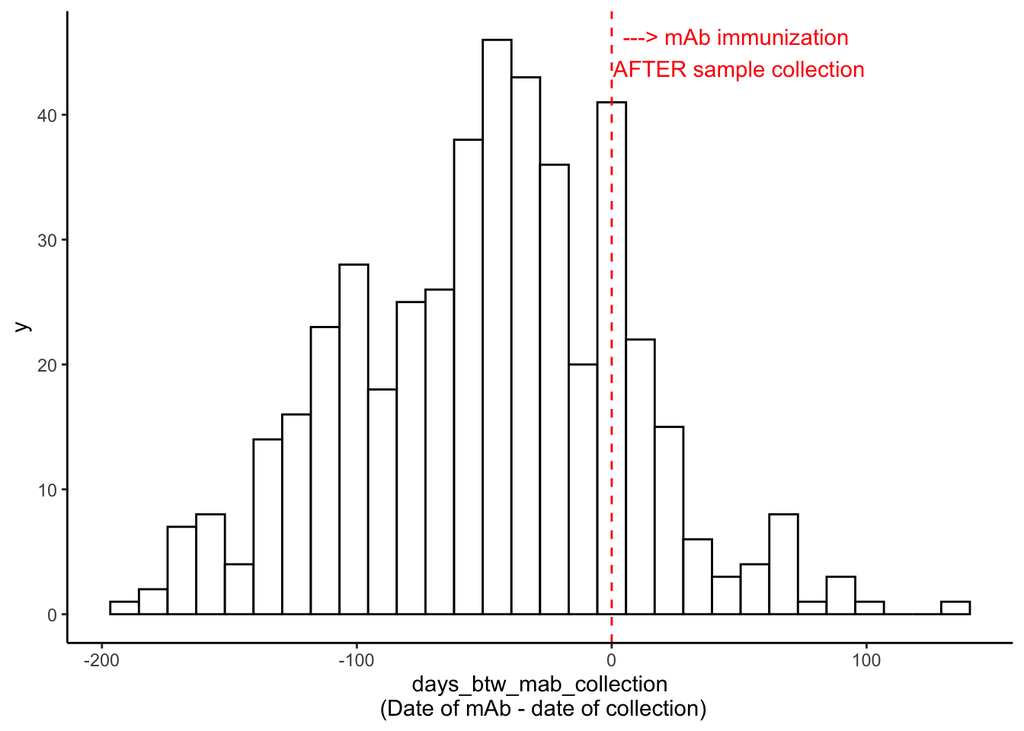

### Those who received mAb within 7 days before sample collection OR received on/after date of collection:

#### (TBC) how do we define exposure? those who are immunized with mAb before sample collection date or those who are immunized >7 days before sample collection date?

| StudyID | days_btw_mab_collection | mAb date | collection_date |
| --- | --- | --- | --- |
| 130735446 | -7 | 2023-11-27T00:00:00Z | 2023-12-04 |
| 130719513 | -6 | 2023-10-27T00:00:00Z | 2023-11-02 |
| 130713961 | -5 | 2023-12-25T00:00:00Z | 2023-12-30 |
| 130728533 | -5 | 2023-10-18T00:00:00Z | 2023-10-23 |
| 130750053 | -5 | 2024-01-20T00:00:00Z | 2024-01-25 |
| 130754819 | -5 | 2023-12-15T00:00:00Z | 2023-12-20 |
| 130755354 | -5 | 2024-01-12T00:00:00Z | 2024-01-17 |
| 130765300 | -5 | 2024-01-23T00:00:00Z | 2024-01-28 |
| 130783493 | -5 | 2024-02-05T00:00:00Z | 2024-02-10 |
| 130755900 | -4 | 2023-12-13T00:00:00Z | 2023-12-17 |

[output cut: 97 more lines]

### Table 25. Nirsevimab status

#### Generated new categorical variables rsv_mab_detailed, to have values of

- 50mg before collection (days_btw_mab_collection < 0)
- 100mg before collection (days_btw_mab_collection < 0)
- 50mg after collection (days_btw_mab_collection >= 0)
- 100mg after collection (days_btw_mab_collection >= 0)
- no mAb recorded but with last hepB vax recorded
- no mAb recorded and no last hepB vax recorded

| rsv_mab_detailed | n_records | perc |
| --- | --- | --- |
| 100mg after collection | 41 | 1.3 |
| 100mg before collection | 102 | 3.1 |
| 50mg after collection | 45 | 1.4 |
| 50mg before collection | 272 | 8.3 |
| no mAb recorded and no last hepB vax recorded | 693 | 21.2 |
| no mAb recorded but with last hepB vax recorded | 2115 | 64.7 |

#### Generated new binary variable rsv_mab from rsv_mab_detailed, to indicate if the record took mAb before collection (TBC), which is to be used as exposure in the analysis:

- 50mg before collection —> 1
- 100mg before collection —> 1
- 50mg after collection —> 0
- 100mg after collection —> 0
- no mAb recorded but with last hepB vax recorded —> 0
- no mAb recorded and no last hepB vax recorded —> 0

| rsv_mab | n_records | perc |
| --- | --- | --- |
| 0 | 2894 | 88.6 |
| 1 | 374 | 11.4 |

### Figure 9. Age at mAb

Generate new variable age_at_mab_in_days (calculated as mAb date in nir tab - DOB ) The figure below only includes records with rsv_mab == 1:

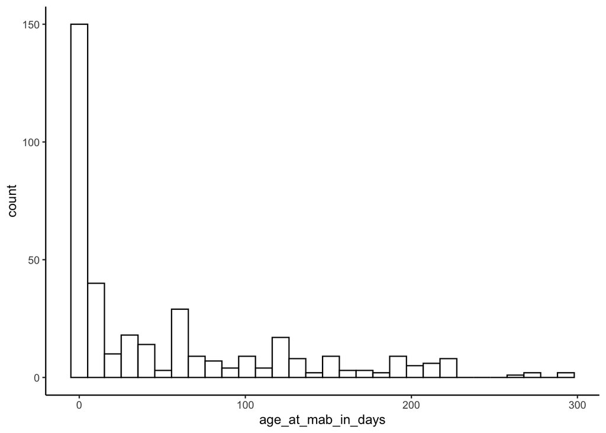

### Read in oxygen volume tab and merge with main tab

### Figure 10. Maximum oxygen flow rate

#### Generate new variable max_oxygen_flowrate (unit: L/min), which threshold to use to indicate severe outcome? TBC

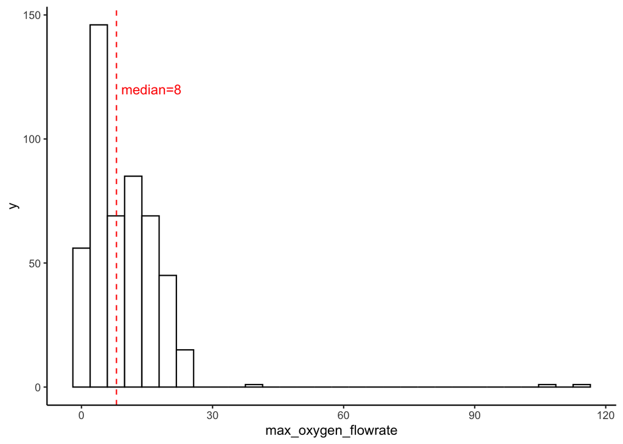

### For each testing record, generate unique testID

#### If a patient was tested multiple times, the testID will has values of StudyID_nthTest (e.g. 99999999_1, 9999999_2..), the suffix indicates the nth test of the patient, ordered by date of sample collection.

Also generated n_tests for each StudyID, to indicate the number of tests this individual took, and generated new variable nth_test to indicate this is the nth test of the same individual patient.

### Table 25. Time since earliest collection for each patient

#### if an individual has multiple tests, for each test, generate new variables:

- days_since_earliest_collection: the time elapse since the earliest test (in days, if this is the first test of a patient, take 0)
- days_since_last_collection: time elapse since the most recent test (in days, if this is the first test of a patient, take 0)
- days_to_next_collection: time to next collection (in days, if this is the last test of a patient, take 0).

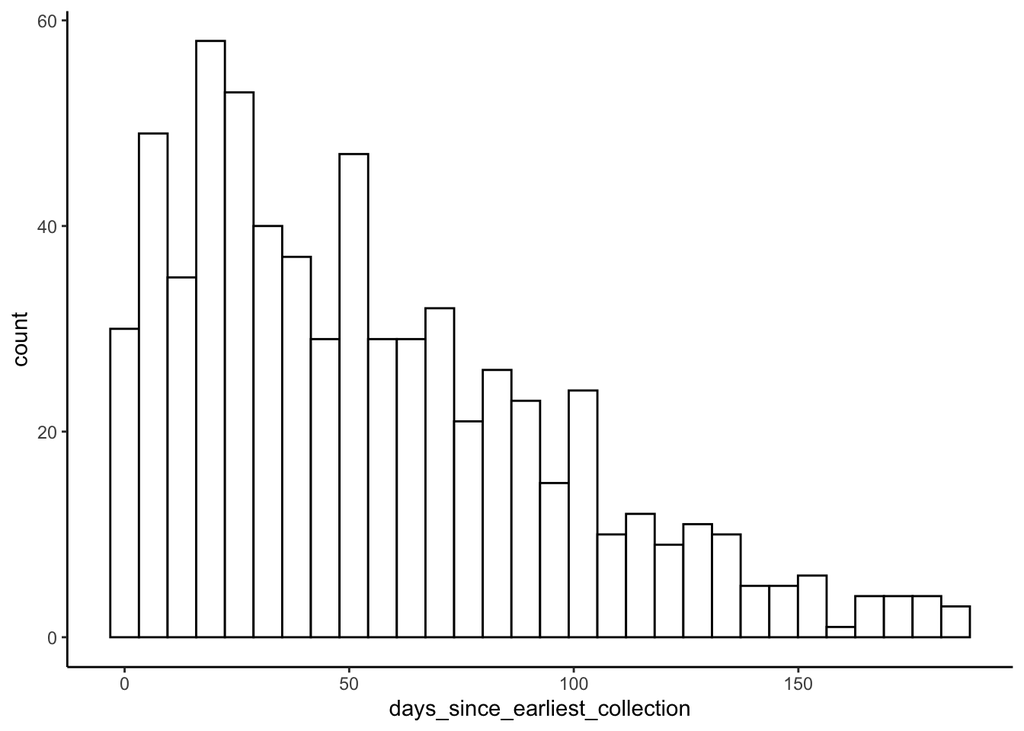

### Table 26. There are several individuals with more than one testing results on the same day. (TBC)

| StudyID | collection_date | Collection Department | tested_viruses | positive_viruses | encounter_type | Admit Date |
| --- | --- | --- | --- | --- | --- | --- |
| 130618601 | 2023-10-23 | LMH EMERGENCY DEPARTMENT | flu rsv | NA | inpatient | 2023-10-23T00:00:00Z |
| 130618601 | 2023-10-23 | YNH WP 7 PEDIATRIC INTENSIVE CARE | flu rhino hmpv adeno parainfluenza rsv | parainfluenza | inpatient | 2023-10-23T00:00:00Z |
| 130696938 | 2023-10-29 | BH EMERGENCY DEPARTMENT | flu rsv | rsv | outpatient | 2023-10-29T00:00:00Z |
| 130696938 | 2023-12-21 | YNH EMERGENCY PEDIATRIC | flu rsv | NA | outpatient | 2023-12-21T00:00:00Z |
| 130696938 | 2023-12-21 | BH FAIRFIELD URGENT CARE | flu rsv | NA | outpatient | 2023-12-21T00:00:00Z |
| 130701204 | 2024-01-20 | BH FAIRFIELD URGENT CARE | flu rsv | rsv | outpatient | 2024-01-20T00:00:00Z |
| 130701204 | 2024-03-29 | BH EMERGENCY DEPARTMENT | flu rsv | NA | outpatient | 2024-03-29T00:00:00Z |
| 130701204 | 2024-03-29 | BH FAIRFIELD URGENT CARE | flu rsv | NA | outpatient | 2024-03-29T00:00:00Z |
| 130726098 | 2023-10-07 | YNH EMERGENCY SHORELINE | flu rsv | rsv | inpatient | 2023-10-07T00:00:00Z |
| 130726098 | 2023-10-07 | YNH EMERGENCY SHORELINE | flu rhino hmpv adeno parainfluenza rsv | rsv | inpatient | 2023-10-07T00:00:00Z |

[output cut: 10 more lines]

### Mark testing records as cases and controls

(reference: https://pubmed.ncbi.nlm.nih.gov/36454733/)

#### Test-positive cases:

- A case of test-positive is defined as a positive RSV test.

#### Test-negative controls:

- Define test-negative control as a negative RSV test
  - collected at any time if this patient was tested only once, **OR**
  - collected > 7 days prior this patient’s next test **AND** collected > 7 days after this patient’s last test (if the patient was tested multiple times)

#### Other notes:

- An individual patient is allowed to contribute as both case and control, as the analysis is to be conducted at test-level, instead of patient-level.
- Each patient can contribute to up to three negative tests (controls) (TBC).
- If a person had more than one negative test within 7-day period, one random test was selected during the period as a control.

```r
##########################
# mark test-positive cases
##########################

df <- df %>% mutate(case_control = ifelse(positive_rsv == 1, "case", NA))

#############################
# mark test-negative controls
#############################

# generate a binary indicator to mark if this patient's next test is RSV positive (didn't use this)
df <- df %>%
  group_by(StudyID) %>%
  mutate(next_test_rsv_positive = lead(positive_rsv)) %>%
  # NA if a person was tested once or this is a last test of an individual
  as.data.frame()


df <- df %>%
  group_by(StudyID) %>%
  mutate(case_control = case_when(
  # 1. the patient was only tested once and was rsv negative
    (positive_rsv == 0 & n_tests == 1) |
  # 2. the patient was tested multiple times:
    # 2.1 if this is not the first or last test of the patient
    # this negative test should be >7 days prior next test AND >7 days after previous test
    (positive_rsv == 0 & n_tests > 1 & days_to_next_collection > 7 & days_since_last_collection > 7) |
    # 2.2 if this is the first test of the patient
    # this negative test should be > 7 days prior next test
    (positive_rsv == 0 & n_tests > 1 & nth_test == 1 & days_to_next_collection > 7) |
    # 2.3 if this is the last test of the patient
    # this negative test should be > 7 days after previous test
    (positive_rsv == 0 & n_tests > 1 & nth_test == n_tests & days_since_last_collection > 7) ~ "control",
    TRUE ~ case_control
  )) %>% as.data.frame()


# If a person had more than one negative test within 7-day period, one random test was selected during the period as a control
set.seed(123)
temp <- df %>%
  group_by(StudyID) %>%
  filter(
    (  ((days_to_next_collection <= 7 | days_since_last_collection <= 7) & nth_test != 1 & n_tests != nth_test) | # tests in the middle
       (nth_test == 1 & days_to_next_collection <= 7) | # first test
       (nth_test == n_tests & days_since_last_collection <= 7) # last test
    ) &  positive_rsv == 0)  %>%
  mutate(n_controls_to_sample_from = n()) %>%
  select(StudyID, n_controls_to_sample_from) %>% unique()


df <- df %>% left_join(temp, by = "StudyID")

# random select one control
randomly.selected.controls.ids <- (df %>%
  filter(n_controls_to_sample_from > 1 & is.na(case_control)) %>%
  group_by(StudyID) %>%
  sample_n(1) %>%
  mutate(control_randomly_selected = 1))$testID

# mark these controls
df <- df %>%
  mutate(randomly_selected_control = ifelse(testID %in% randomly.selected.controls.ids, 1, 0)) %>%
  mutate(case_control = ifelse(randomly_selected_control == 1, "control", case_control))

# # individual patients contribute more than three controls (n = 17)
# df %>%
#   group_by(StudyID) %>%
#   count(case_control) %>%
#   filter(n>1) %>%
#   arrange(desc(n), StudyID) %>%
#   filter(case_control == "control") %>%
#   filter(n > 3)
```

### Table 27 Take a look at number of cases and controls.

| case_control | n | perc |
| --- | --- | --- |
| case | 735 | 22.5 |
| control | 2462 | 75.3 |
| NA | 71 | 2.2 |

### Table 28. There are patients who contributed 2 cases.

#### (TBC) Should we include all test-positive records as cases? Or if the two test-positive results for the same individual happened within 7(?) days, we only keep one case for this individual?

| StudyID | collection_date | tested_viruses | positive_viruses | case_control |
| --- | --- | --- | --- | --- |
| 130599389 | 2023-12-01 | flu rsv | rsv | case |
| 130599389 | 2023-12-13 | flu rsv | fluA rsv | case |
| 130614123 | 2023-10-23 | flu rsv | rsv | case |
| 130614123 | 2023-10-24 | flu rsv | rsv | case |
| 130614123 | 2024-01-03 | flu rsv | NA | control |
| 130615212 | 2023-12-11 | flu rhino hmpv adeno parainfluenza rsv | adeno rsv | case |
| 130615212 | 2024-01-02 | flu rhino hmpv adeno parainfluenza rsv | adeno rsv | case |
| 130616469 | 2023-11-16 | flu rsv | rsv | case |
| 130616469 | 2023-12-21 | flu rsv | rsv | case |
| 130621642 | 2023-11-04 | flu rsv | rsv | case |

[output cut: 55 more lines]

### Table 29. briefly look at risk factors by mAb status

|  | 0 (N=2894) | 1 (N=374) | P-value |
| --- | --- | --- | --- |
| factor(Sex) |  |  |  |
| Female | 1255 (43.4%) | 158 (42.2%) | 0.718 |
| Male | 1638 (56.6%) | 216 (57.8%) |  |
| Missing | 1 (0.0%) | 0 (0%) |  |
| age_at_test_in_months |  |  |  |
| Mean (SD) | 6.51 (3.35) | 3.96 (2.76) | <0.001 |
| Median [Min, Max] | 6.70 [0, 12.0] | 3.40 [0.100, 12.0] |  |
| factor(encounter_type) |  |  |  |
| inpatient | 536 (18.5%) | 96 (25.7%) | 0.00125 |
| outpatient | 2327 (80.4%) | 274 (73.3%) |  |
| Missing | 31 (1.1%) | 4 (1.1%) |  |
| factor(insurance_type) |  |  |  |
| private | 1034 (35.7%) | 94 (25.1%) | <0.001 |
| public | 1843 (63.7%) | 280 (74.9%) |  |
| uninsured | 17 (0.6%) | 0 (0%) |  |
| factor(risk_factor_gestage) |  |  |  |
| early term | 722 (24.9%) | 108 (28.9%) | <0.001 |
| full term | 1067 (36.9%) | 119 (31.8%) |  |
| late term | 143 (4.9%) | 12 (3.2%) |  |
| post term | 2 (0.1%) | 0 (0%) |  |
| preterm | 306 (10.6%) | 106 (28.3%) |  |
| Missing | 654 (22.6%) | 29 (7.8%) |  |
| factor(risk_factor_cvd) |  |  |  |
| 1 | 217 (7.5%) | 50 (13.4%) | <0.001 |
| Missing | 2677 (92.5%) | 324 (86.6%) |  |
| factor(risk_factor_gi) |  |  |  |
| 1 | 150 (5.2%) | 40 (10.7%) | <0.001 |
| Missing | 2744 (94.8%) | 334 (89.3%) |  |
| factor(risk_factor_pulmonary) |  |  |  |
| 1 | 147 (5.1%) | 26 (7.0%) | <0.001 |
| Missing | 2747 (94.9%) | 348 (93.0%) |  |
| factor(risk_factor_asthma) |  |  |  |
| 1 | 102 (3.5%) | 8 (2.1%) | <0.001 |
| Missing | 2792 (96.5%) | 366 (97.9%) |  |
| factor(risk_factor_anemia) |  |  |  |
| 1 | 69 (2.4%) | 10 (2.7%) | <0.001 |
| Missing | 2825 (97.6%) | 364 (97.3%) |  |